# 第5回 ベイズ勉強会：MCMC

Taka-aki Asano

2017/5/15

# 準備

今回使用しているパケージは以下の通り。

```r
library("ggplot2")
library("grid")
library("Rmisc")
```

Macの人が図に日本語を入れたいときは、以下のコードを事前に走らせておく。

```r
quartzFonts(HiraKaku = quartzFont(rep('Hiragino Kaku Gothic Pro W3', 4)))
theme_set(theme_gray(base_size = 12, base_family = 'HiraKaku'))
```

# メトロポリス法をめぐる個人的な体験

BDAの例でなくて恐縮だが、以下ではKruschke (2014) “*Doing Bayesian Data Analysis*” において、メトロポリス法の説明で出てきた例を実装する。あえてBDAに出てきていない例を取り上げるのには理由がある。約半年前、この事例を使った課題が矢内先生の授業で出題されたとき、以下のような「問題」が起きたのである。

矢内先生「今日は淺野さんが提出したコードを使って授業します。淺野さんのコード、どっか間違ってると思うんですけど。」  
淺野「えっ、どこですか…？」  
矢内先生「ランダムウォークで得た事後分布、想定されてる形とちょっと違いませんか？」  
淺野「確かにちょっと違うような気も？でも、コードは合ってると思うのですが。試行回数が少なくて収束してないのでは？」  
矢内先生「えっ、そうかな？コードが間違ってる気がするんですけど」

結局、この問題は特に解決されずに終わってしまった。ということで、コードが間違っていたのか、はたまた試行回数が足りなかっただけなのかを、この機会に再検討したい。「そんなの勝手にやってくれ」とのお声も聞こえてきそうだが、シミュレーションの試行回数をどの程度にすべきか、そもそもメトロポリス法がどういう手法かについて理解を深めることにも繋がると言い訳し、書かせていただく。

それでは、Kruschke (2014) がどのような例を挙げていたのか、簡単に説明する。

1. 政治家は選挙活動のために、東西に並ぶ7つの島を巡りたい。しかし、政治家は各島の人口分布を知らない。そこで、島を$\theta = \{1, 2, \dots, 7\}$とし、ランダムウォークによって人口分布$q(\theta)$を得よう。
2. 最初に訪れる島を適当にきめる。この島を$\theta_c$とする。
3. コイントスを行い、表が出たら$\theta_c + 1$、裏が出たら$\theta_c - 1$を移動候補とする。なお、候補の島を$\theta_p$とする。
4. ここで、現在の島の人口$q(\theta_c)$と候補の島の人口$q(\theta_p)$の情報を入手する。
5. 移動するかどうかを、入手した人口の情報から以下の要領で決める。  
   $q(\theta_c) < q(\theta_p)$のとき：移動  
   $q(\theta_c) \geq q(\theta_p)$のとき：$\frac{q(\theta_p)}{q(\theta_c)}$の確率で移動
6. 2〜4を繰り返す。なお、政治家は移動したら人口の情報を忘れてしまうものとする。

矢内先生の課題は、島の数を15、各島の人口を島の番号と同じ（つまり$q(\theta = 1) = 1$と設定した上で、ランダムウォークを行わせて人口分布を得ろというものだった。これに対して、淺野が提出したコードが以下である。

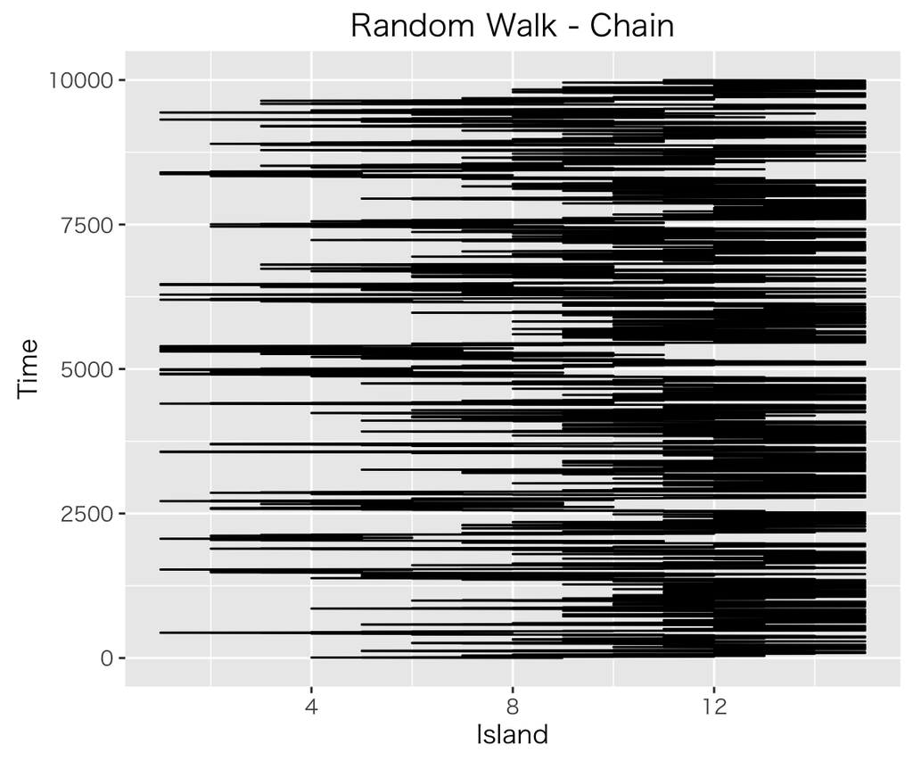

```r
# algorithm
pol_jump <- function(n_sims = 100, init = sample(1:15, size = 1)) {
  ## Assume there exist 0th and 15th islands that are uninhabited
  pop <- c(0, 1:15, 0)
  ## the initial island
  current <- init
  ## make dataframe for saving results
  res_df <- data.frame(time = 1:n_sims,
                       visited = rep(NA, n_sims))
  ## the current island
  res_df$visited[1] <- current
  ## simulation of moving
  for (t in 2:n_sims){
    proposed <- current + ifelse(rbinom(1, 1, prob = .5), 1, -1)
    prob_move <- min(1, pop[proposed + 1] / pop[current + 1])
    current <- ifelse(runif(1, 0, 1) < prob_move, proposed, current)
    res_df$visited[t] <- current
  }
  return(res_df)
}

# simulation
res <- pol_jump(n_sims = 10000)

# show result as line graph
trace1 <- ggplot(res, aes(x = time, y = visited)) +
  geom_line() + coord_flip() +
  ylab("Island") + xlab("Time") +
  ggtitle("Random Walk - Chain")
print(trace1)
```

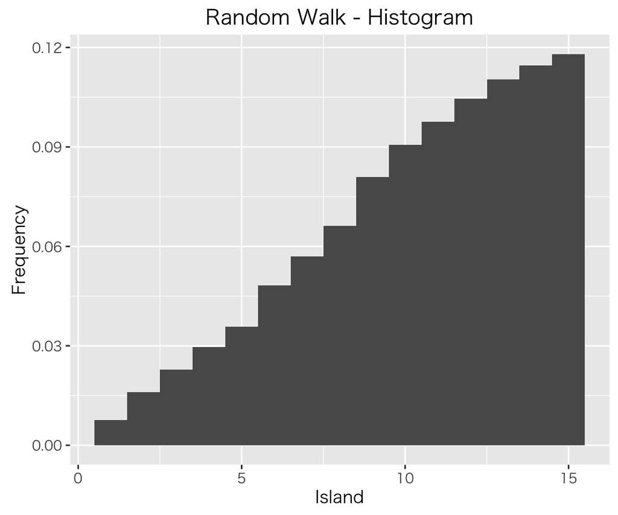

```r
# show result as histogram
histogram1 <- ggplot(res[5001:10000,],
                     aes(x = visited, y = ..density..)) +
  geom_histogram(binwidth = 1) +
  xlab("Island") + ylab("Frequency") +
  ggtitle("Random Walk - Histogram")
print(histogram1)
```

なるほど、確かに10000回も移動したわりには、予測される人口分布は現実と微妙に異なっても見える。しかし、密かに悔しかった淺野はその後しばらく、神戸大の食堂で「自分のコード自体は間違ってない！」という思いを胸に試行錯誤する。その結果、「移動回数が足りてないだけ」という仮説を検証するべく、以下の関数を作った。

```r
# make a function for confirming that politician moves between islands according to the ratio of population
visit_ratio <- function(visit = 10000, trial = 100) {
  ## make dataframe for saving results
  res_df <- data.frame(island2 = rep(NA, trial), island3 = rep(NA, trial),
                       island4 = rep(NA, trial), island5 = rep(NA, trial),
                       island6 = rep(NA, trial), island7 = rep(NA, trial),
                       island8 = rep(NA, trial), island9 = rep(NA, trial),
                       island10 = rep(NA, trial), island11 = rep(NA, trial),
                       island12 = rep(NA, trial), island13 = rep(NA, trial),
                       island14 = rep(NA, trial), island15 = rep(NA, trial))
  ## visit between islands
  for (i in 1:trial) {
    ### Assume there exist 0th and 16th islands that are uninhabited
    pop <- c(0, 1:15, 0)
    ### make dataframe for recording visited island
    visited <- rep(NA, visit)
    ### the initial island
    visited[1] <- sample(1:15, size = 1)
    ### simulation of moving
    for (t in 2:visit){
      current <- visited[t-1]
      ### proposed = current + 1 or current - 1
      proposed <- current + sample(c(-1, 1), 1)
      ### the probability of visitng the proposed island
      ### the population of the nth island is pop[n+1]
      prob_move <- min(1, pop[proposed + 1] / pop[current + 1])
      ### wether politician moves or not
      ### 0 = stay, 1 = move
      move <- rbinom(1, 1, prob_move)
      ### when move = 1, insert proposed
      ### when move = 0, insert current
      visited[t] <- ifelse(move == 1, proposed, current)
    }
    ### the frequency of visiting 1st island
    island_1 <- sum(visited == 1)
    ### make vector for saving calculation
    ratio <- rep(NA, 14)
    for (j in 2:15) {
      ### the frequency of visiting jth island
      island_j <- sum(visited == j)
      ### calculate the ratio of 1st island to jth island
      ratio[j-1] <- island_j / island_1
    }
    ## save result
    res_df[i,] <- ratio
  }
  return(res_df)
}
```

何をやっているのかというと、$\theta = 1$の島に対して、各島にどのくらい訪れたかの比率を計算させている。この関数を使い、10000回移動するランダムウォークを200回繰り返させた結果が、以下である。

```r
# run a simulation again
res2 <- visit_ratio(visit = 10000, trial = 200)
head(res2)
```

```
##    island2  island3  island4  island5  island6  island7  island8  island9
## 1 1.731707 2.544715 3.195122 3.495935 4.000000 4.585366 5.154472 6.056911
## 2 1.863309 2.388489 2.827338 3.230216 3.618705 4.273381 4.906475 5.467626
## 3 1.663043 2.467391 3.543478 4.945652 5.750000 6.858696 8.163043 9.065217
## 4 2.084337 3.506024 5.433735 6.710843 7.397590 8.409639 9.638554 9.819277
## 5 1.698795 2.698795 4.313253 6.000000 6.867470 8.144578 8.927711 9.662651
## 6 1.586538 2.490385 3.153846 3.836538 4.634615 5.615385 6.298077 7.307692
##    island10  island11  island12  island13  island14  island15
## 1  7.073171  7.544715  7.626016  8.130081  9.186992  9.975610
## 2  5.517986  6.093525  7.294964  7.863309  7.755396  7.841727
## 3  9.945652 10.184783 10.739130 11.304348 11.586957 11.478261
## 4 10.012048 10.373494 10.216867 10.975904 11.710843 13.192771
## 5 10.843373 11.000000 11.409639 11.795181 12.481928 13.638554
## 6  8.519231  8.980769  9.596154 10.346154 10.894231 11.894231
```

```r
# mean of ratio
Mean <- rep(NA, 14)
for (i in 1:14) {
  Mean[i] <- mean(res2[,i])
}
Mean
```

```
##  [1]  2.082277  3.204616  4.357619  5.530261  6.614586  7.736337  8.893739
##  [8] 10.079057 11.228532 12.362619 13.444989 14.532610 15.638242 16.759175
```

```r
# variance of ratio
Var <- rep(NA, 14)
for (i in 1:14) {
  Var[i] <- var(res2[,i])
}
Var
```

```
##  [1]  0.1573101  0.6813965  1.7545283  3.2238404  4.9765400  7.1586774
##  [7]  9.7975516 13.1962473 17.4338366 21.7226328 25.3761069 29.9201164
## [13] 35.7531444 41.7673635
```

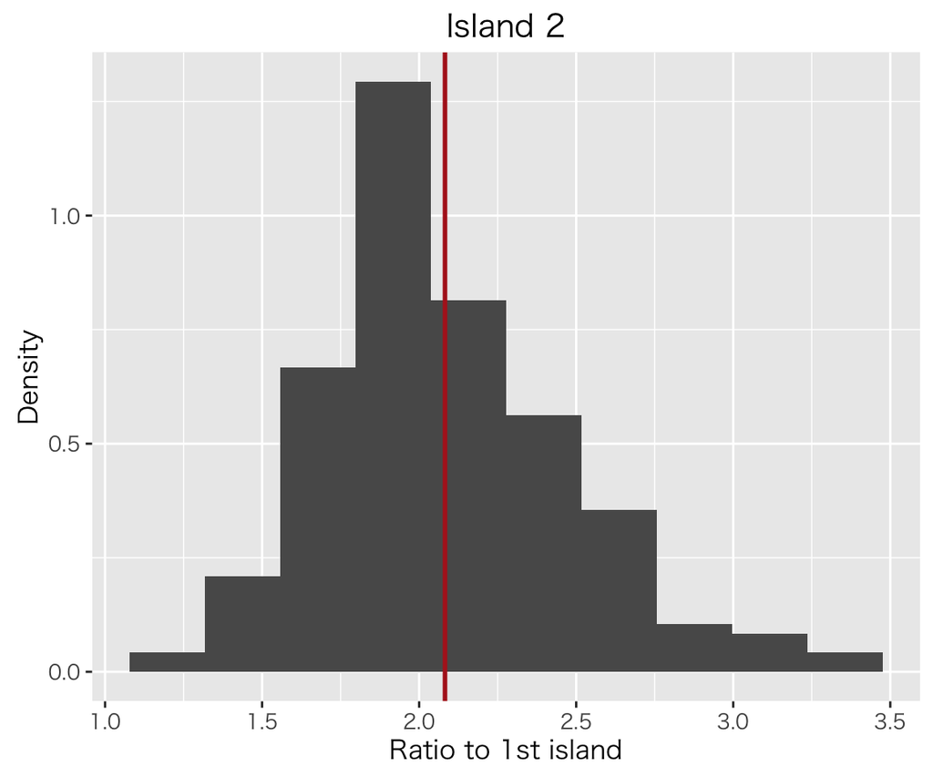

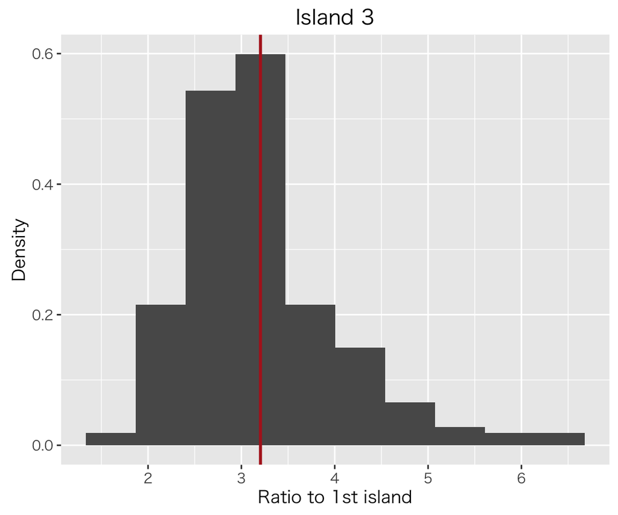

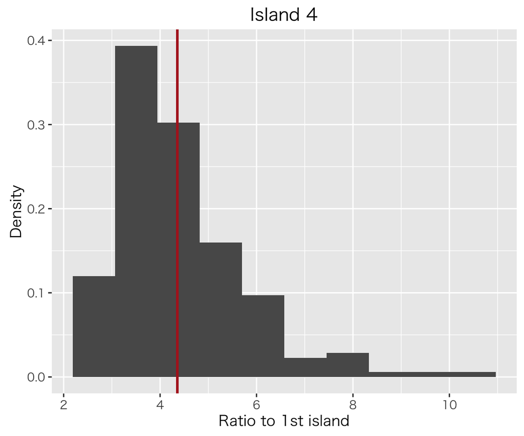

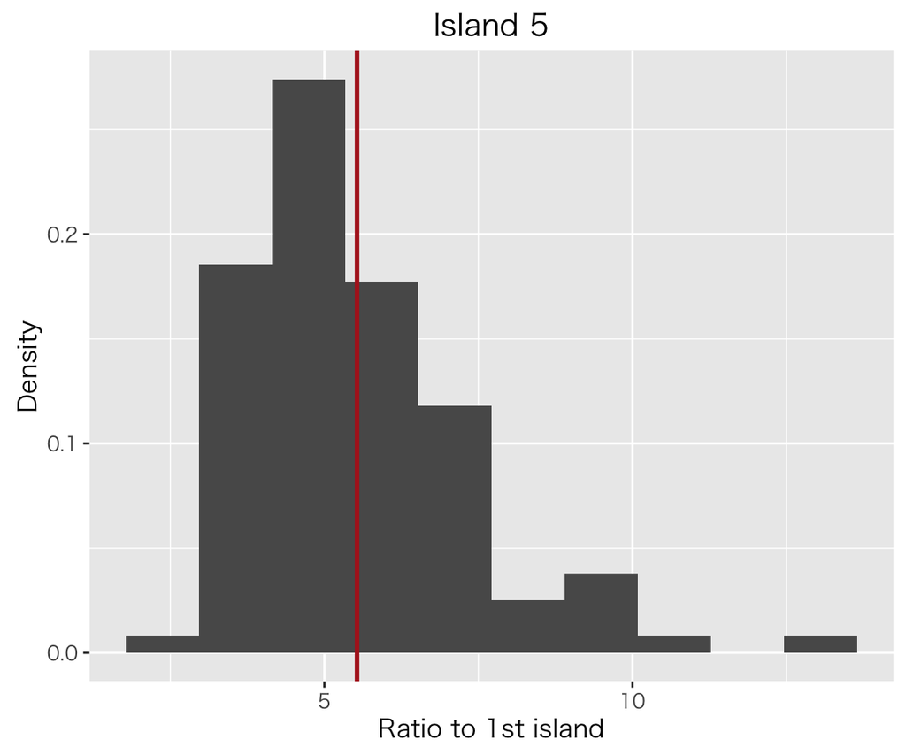

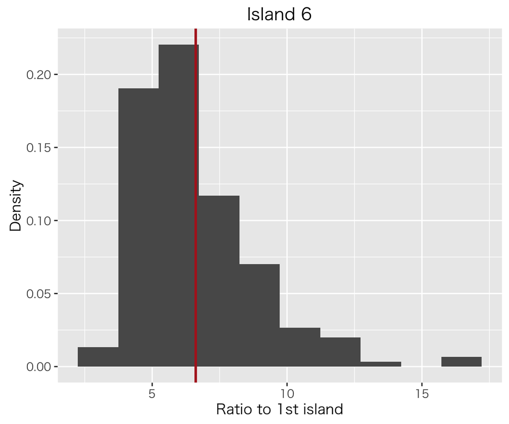

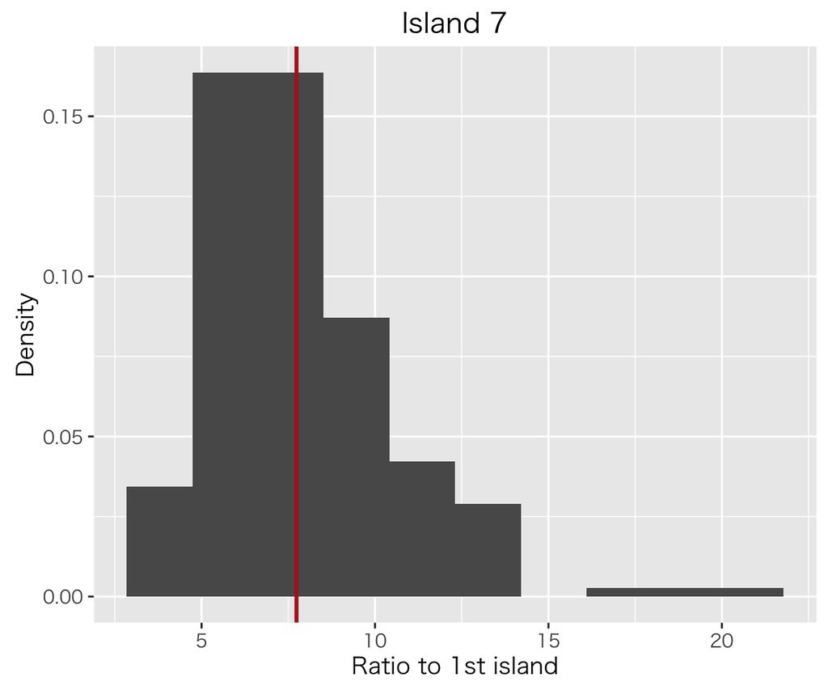

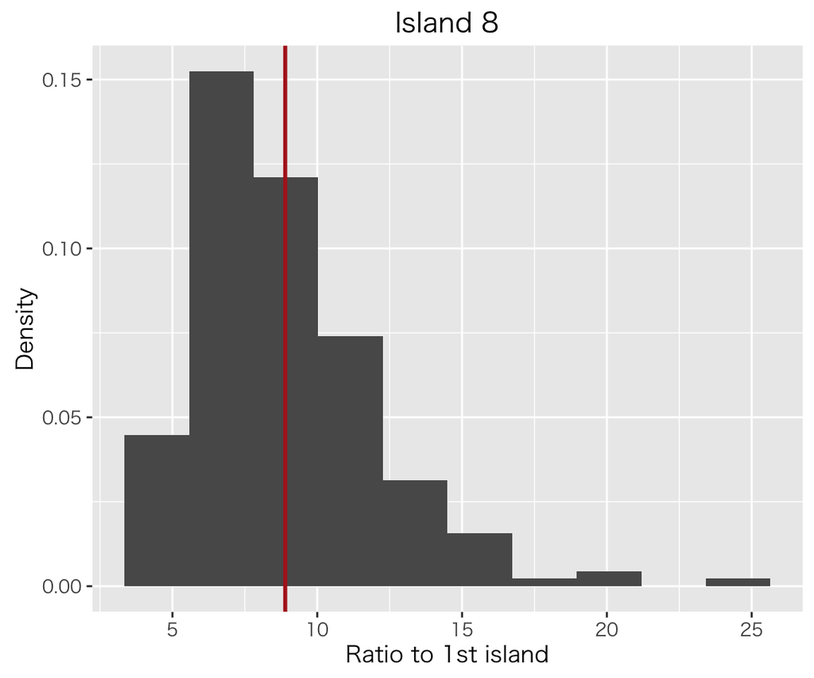

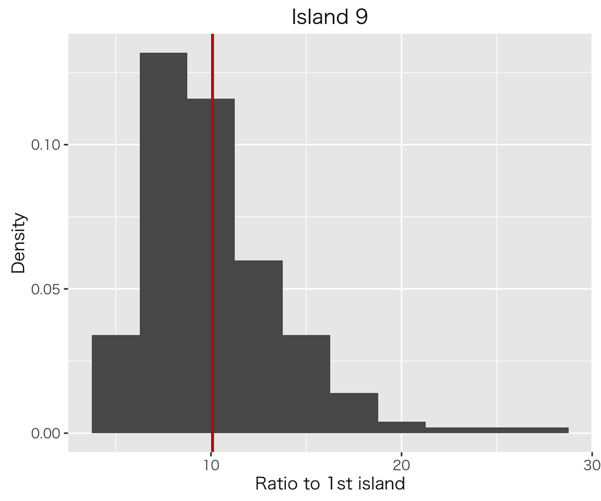

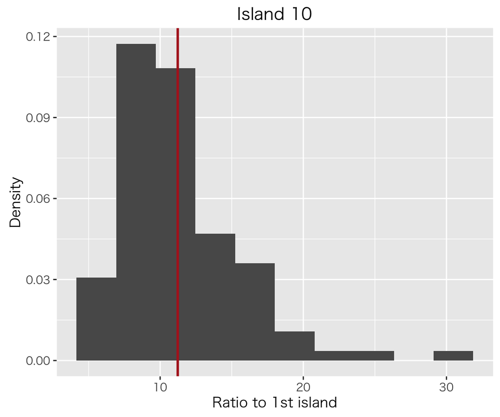

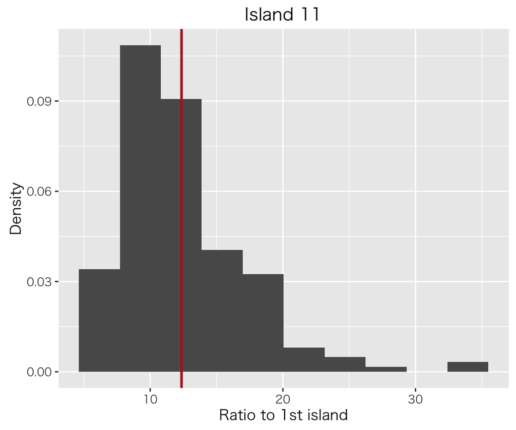

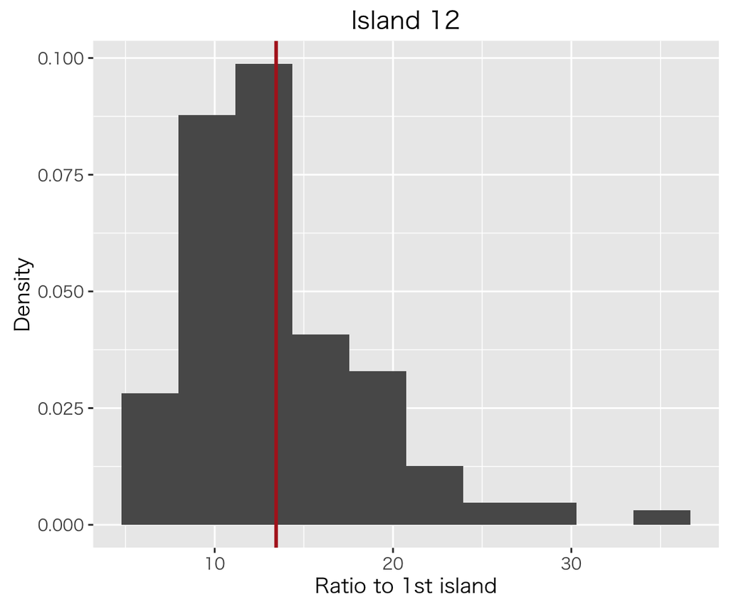

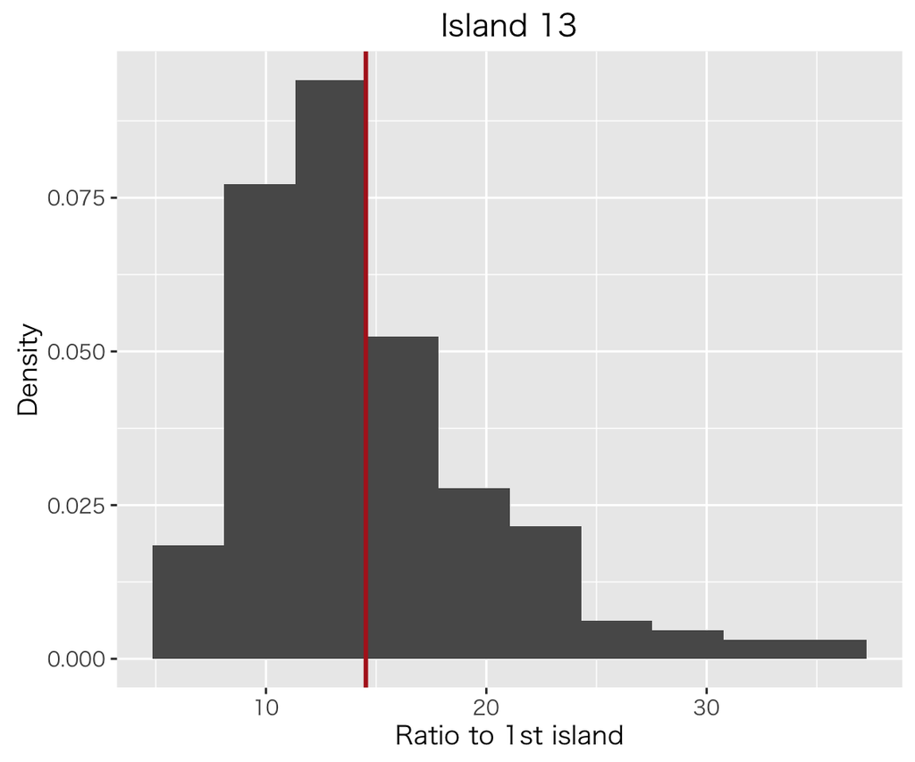

[2 more figures not shown]

```r
# histogram of ratio
## new empty list for saving plots
plots <- list()
## plot
for (i in 1:14) {
  res_p <- data.frame(ratio = res2[,i])
  histogram <- ggplot(res_p,
                      aes(x = ratio, y = ..density..)) +
    geom_histogram(bins = 10) +
    geom_vline(xintercept = mean(res_p$ratio), color = "firebrick", size = 1) +
    labs(title = paste("Island", i+1), y = "Density", x = "Ratio to 1st island")
  plots[[i]] <- histogram
  print(plots[[i]])
}
```

ヒストグラムの赤線は、シミュレーションされた1の島との平均人口比である。見ると、人口が多くなるほどズレが顕著になっている。このズレが1回あたりの移動回数を増やすことで改善されれば、ランダムウォークの回数が少なかっただけだと言えそうだ。そこで、思い切って100000回移動するランダムウォークを200回シミュレーションしてみる。なお、作業に割と時間がかかるので、実行される時には注意して欲しい。

```r
# visit between islands at more time
res3 <- visit_ratio(visit = 100000, trial = 200)
head(res3)
```

```
##    island2  island3  island4  island5  island6  island7  island8   island9
## 1 2.021144 3.063433 4.004975 4.944030 5.944030 7.024876 7.901741  9.054726
## 2 2.075000 3.057500 4.105000 5.243750 6.333750 7.183750 8.211250  9.222500
## 3 2.129730 3.258108 4.441892 5.632432 6.574324 7.514865 8.804054 10.147297
## 4 2.001368 3.146375 4.389877 5.586867 6.990424 8.028728 9.160055 10.485636
## 5 1.984356 2.956679 4.001203 5.046931 6.092659 7.190132 8.237064  9.296029
## 6 1.971710 3.070111 4.194342 5.173432 6.147601 7.182042 8.210332  9.403444
##   island10 island11 island12 island13 island14 island15
## 1 10.58458 11.77239 12.81592 13.90050 14.72886 15.61692
## 2 10.27250 11.55875 12.79875 13.68000 14.56625 15.69125
## 3 11.28919 12.38649 13.64054 14.91622 16.09459 17.30541
## 4 11.78523 12.85363 13.72230 14.58276 15.81395 17.25171
## 5 10.28761 11.30927 12.26474 12.83995 13.54392 14.28640
## 6 10.35301 11.31734 12.28167 13.14022 14.19803 15.35793
```

```r
# mean of ratio
Mean <- rep(NA, 14)
for (i in 1:14) {
  Mean[i] <- mean(res3[,i])
}
Mean
```

```
##  [1]  2.002946  3.008843  4.021251  5.035967  6.044946  7.045915  8.056706
##  [8]  9.070938 10.077182 11.067969 12.088428 13.109278 14.114793 15.140569
```

```r
# variance of ratio
Var <- rep(NA, 14)
for (i in 1:14) {
  Var[i] <- var(res3[,i])
}
Var
```

```
##  [1] 0.01169064 0.05115758 0.12105439 0.21920734 0.36185339 0.52975592
##  [7] 0.73803946 1.03344015 1.37548791 1.73462958 2.12912413 2.56907862
## [13] 3.00106035 3.41388589
```

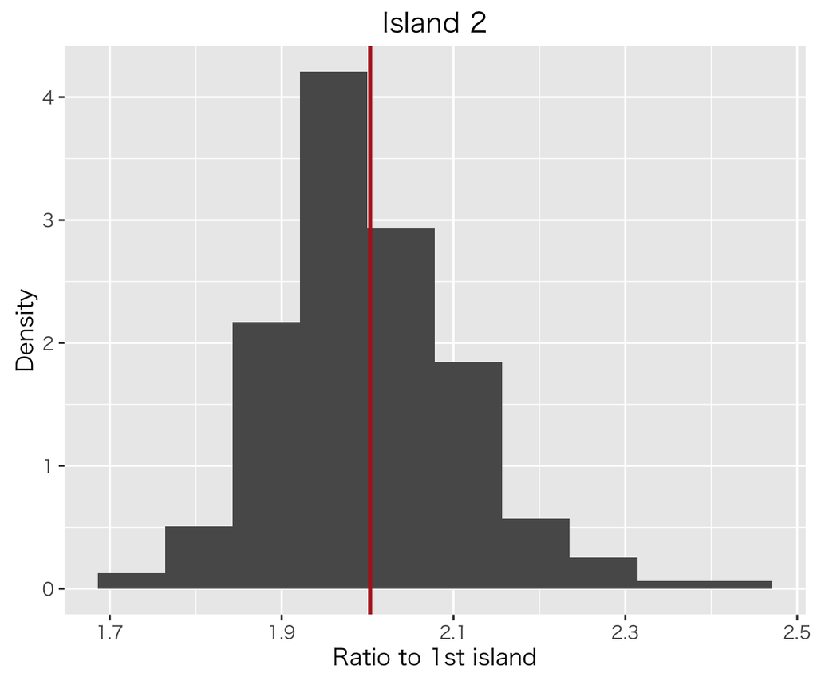

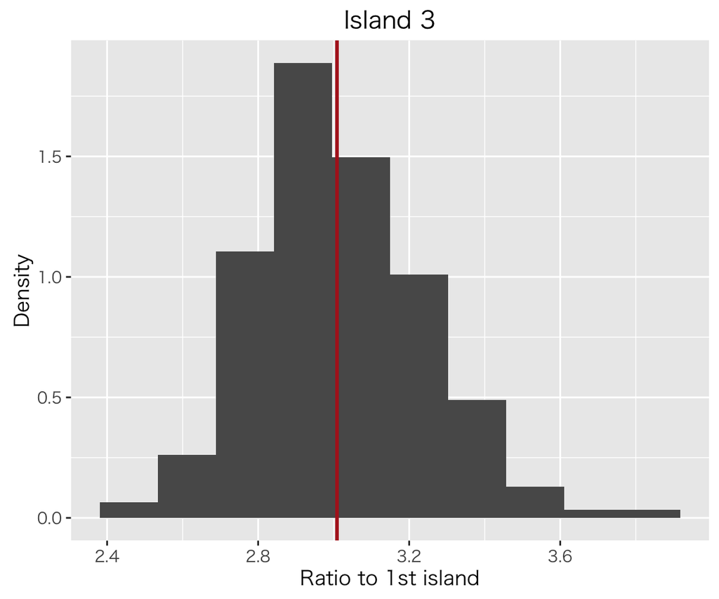

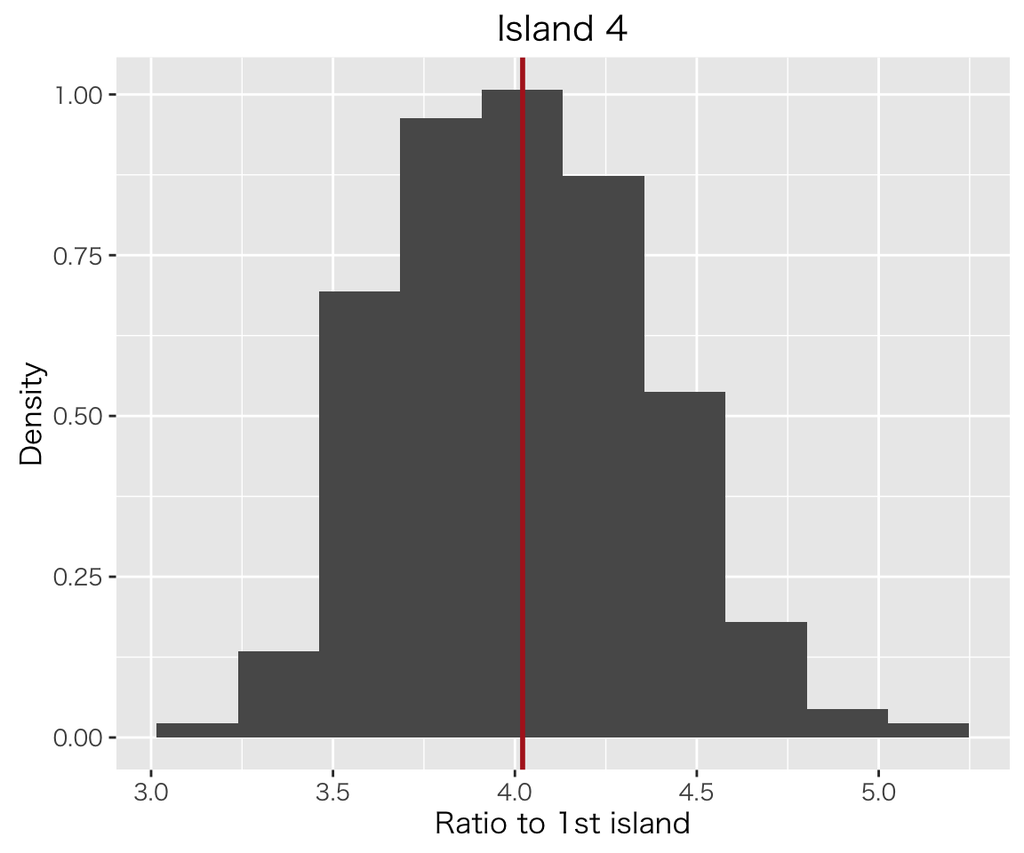

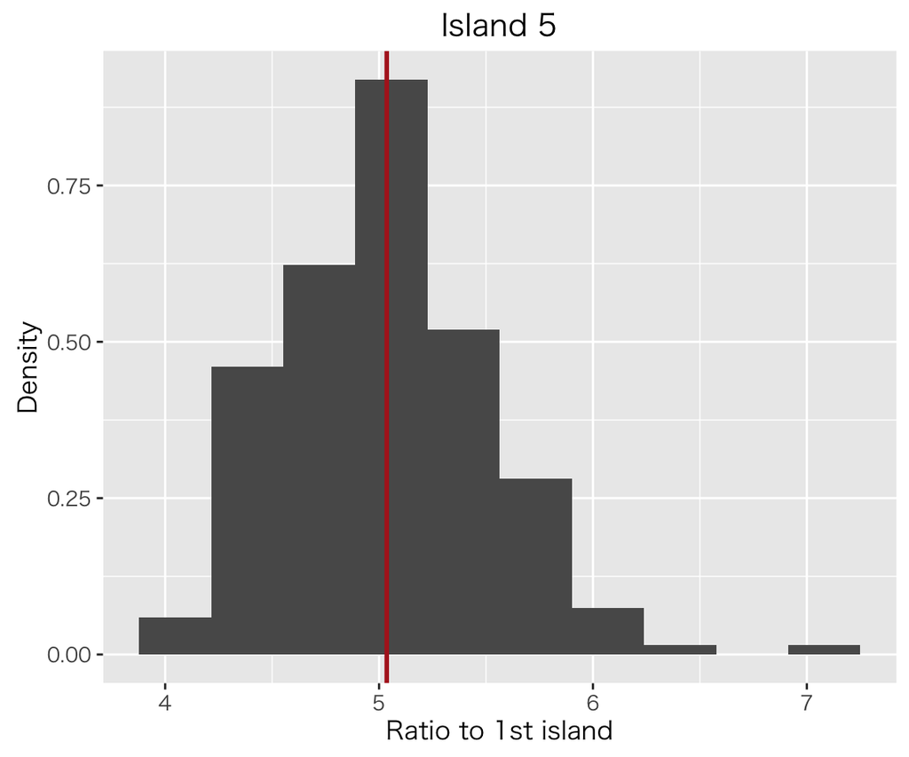

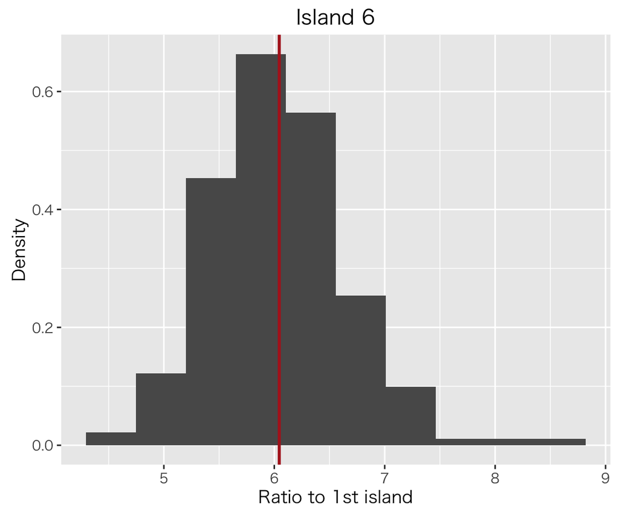

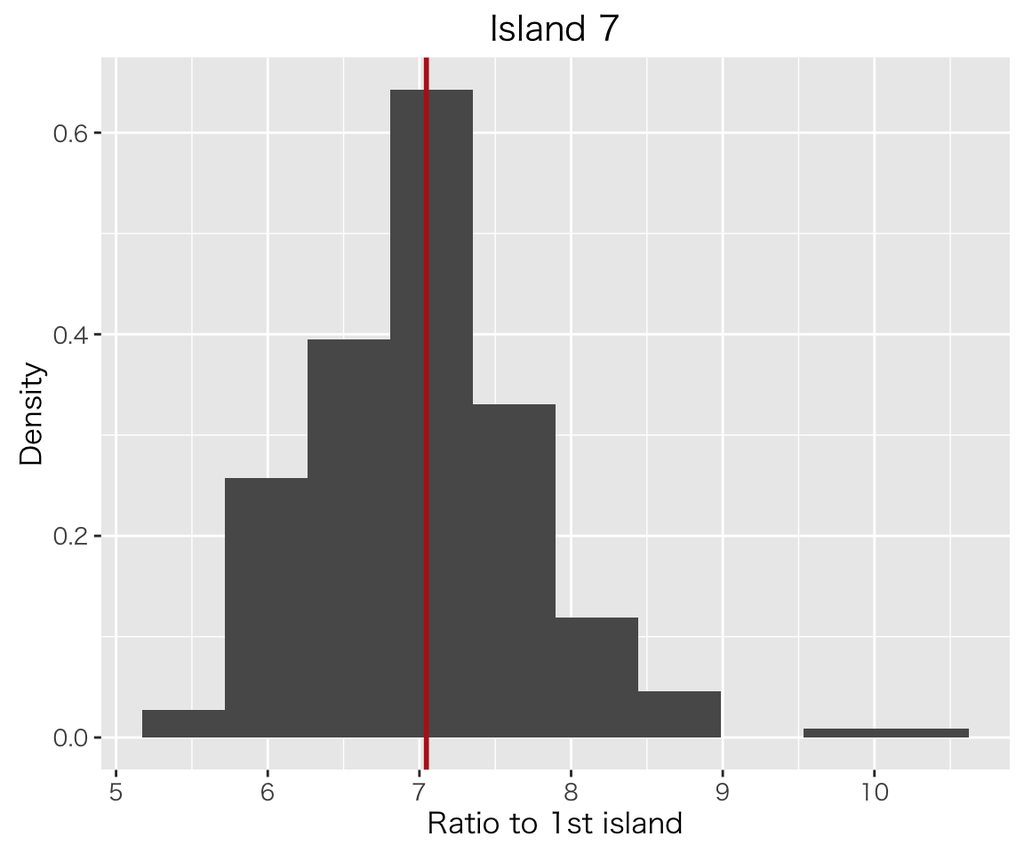

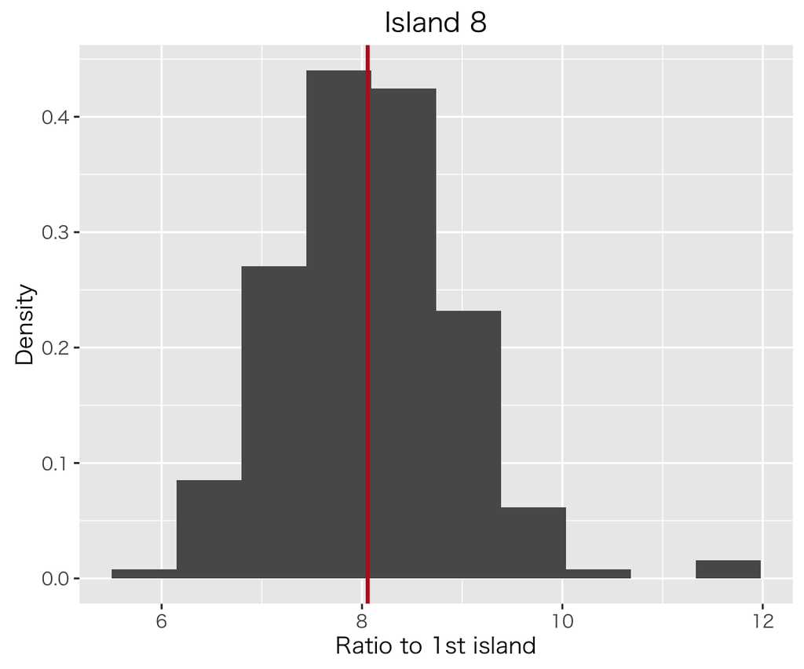

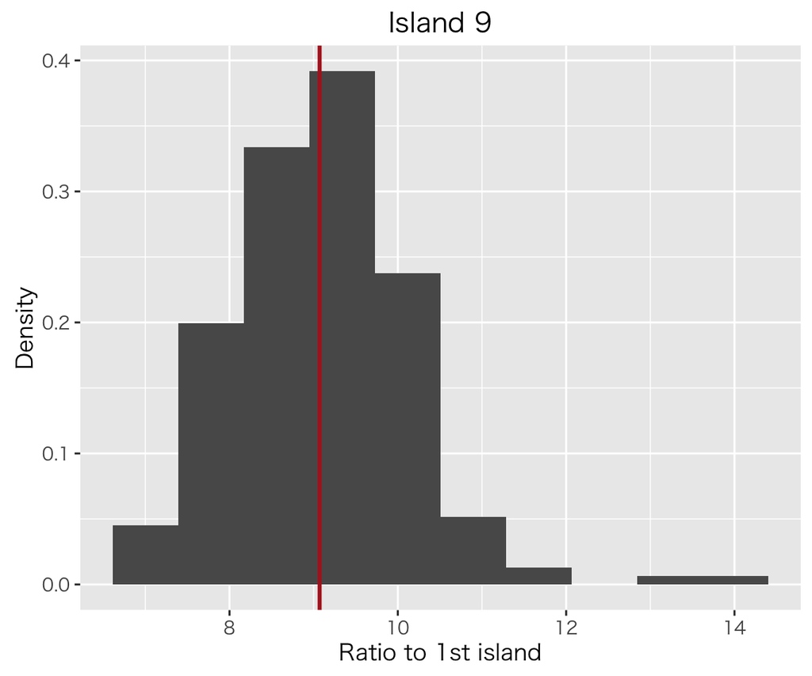

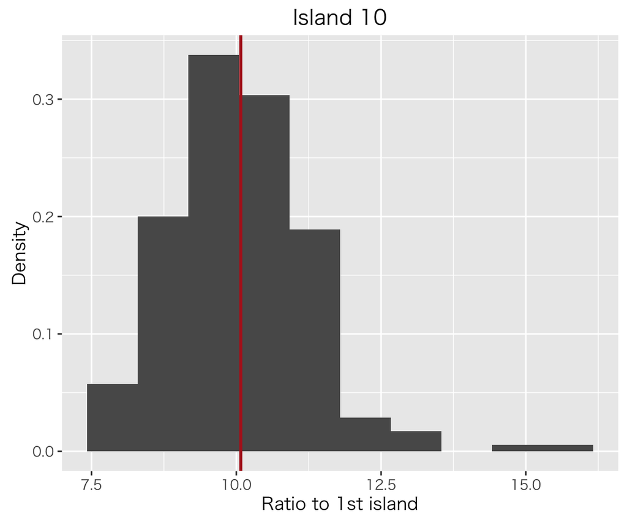

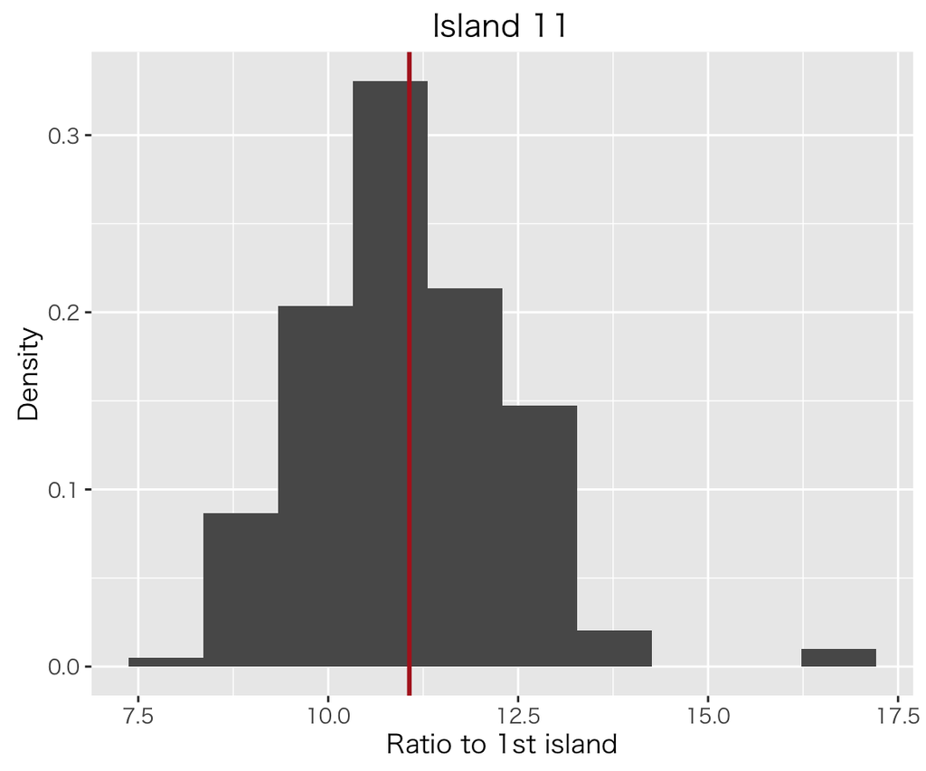

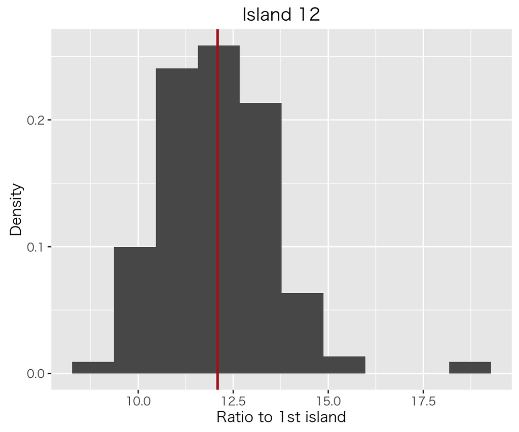

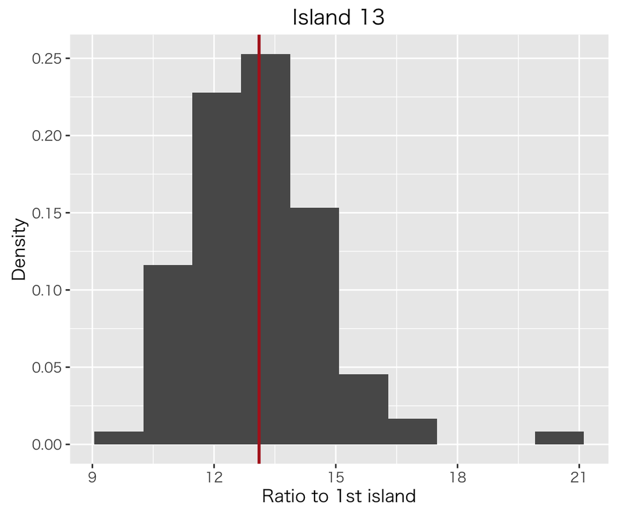

[2 more figures not shown]

```r
# histogram of ratio
# new empty list for saving plots
plots <- list()
# plot
for (i in 1:14) {
  res_p <- data.frame(ratio = res3[,i])
  histogram <- ggplot(res_p,
                      aes(x = ratio, y = ..density..)) +
    geom_histogram(bins = 10) +
    geom_vline(xintercept = mean(res_p$ratio), color = "firebrick", size = 1) +
    labs(title = paste("Island", i+1), y = "Density", x = "Ratio to 1st island")
  plots[[i]] <- histogram
  print(plots[[i]])
}
```

移動回数を増やすと、予測される数値に収束しつつあることが分かる。やはり、コードが間違っているのではなく、移動回数が足りなかったのではないだろうか？ただ、収束させるのに10万回も必要というのは、メトロポリス法も大変なものだ。なお、この結果を矢内先生に送ろうと思っていたが、「どうせ僕が間違ってるかも」「何かタイミングつかめない」と、見事なチキンぶりを発揮し、今日までコマンドだけがひっそり残っていた。

# コイントスを例にした実装

上の「個人的な体験」を書いているうちに、思いの外時間がなくなってしまった。MH法とギブス・サンプリングから事後分布を得る流れを、BDAの例から実装したかったが、間に合いそうにない。コイントスを例にした簡単な例を昔作っていたので、改良して載せておく。

## メトロポリス・ヘイスティングス法

コイントスを行って表が出る確率を$\theta$とする。ここで、10回のコイントスで3回表が出た。このときの尤度は、
$$3 | \theta \sim \mbox{Bin}(10, \theta)$$
である。また、$\theta$の事前分布を、
$$\theta \sim \mbox{Beta}(1, 1)$$
とおく。このとき、
$$p(\theta | y) \propto p(y | \theta)p(\theta) = \theta^{3+1-1} (1 - \theta)^{7+1-1}$$
となる。事後分布を計算するためには$p(y)$が必要であるが、メトロポリス・ヘイスティングス法をうまく使って$p(y | \theta)p(\theta)$から事後分布を得てみよう。

今回は以下のランダムウォークを行う。

1. 最初の$\theta$の値を適当にきめる。これを$\theta_c$とする。
2. $\mbox{Normal}(0, 0.1^2)$の分布から値を抽出し、$\theta_c$に加える。加えた値は$\theta$の移動先の候補となる。それを$\theta_p$とする。
3. 移動するかどうかを、以下の要領で決める。  
   $\theta_c^3 (1 - \theta_c)^7 < \theta_p^3 (1 - \theta_p)^7$のとき：移動  
   $\theta_c^3 (1 - \theta_c)^7 \geq \theta_p^3 (1 - \theta_p)^7$のとき：$\frac{\theta_p^3 (1 - \theta_p)^7}{\theta_c^3 (1 - \theta_c)^7}$の確率で移動
4. 2〜3を繰り返す。

実際にRでシミュレーションしてみよう。

```r
# define unnormalized density
unnorm <- function(theta) {
  if (theta < 0 | theta > 1) return(0)
  else return(theta^3 * (1 - theta)^7)
}

# MH Algorithm function
coin_sim <- function(n_sims = 100, init = runif(1, 0, 1)) {
    current <- init
    res_df <- data.frame(time = 1:n_sims,
                         post_theta = rep(NA, n_sims))
    res_df$post_theta[1] <- current
    for (t in 2:n_sims) {
        prop <- current + rnorm(1, mean = 0, sd = .1)
        # use log because the nonnorm can be very small
        log_r <- log(unnorm(prop)) -log(unnorm(current))
        prob_move <- min(1, exp(log_r))
        current <- ifelse(runif(1, 0, 1) < prob_move, prop, current)
        res_df$post_theta[t] <- current
    }
    return(res_df)
}

# simulation
sim <- coin_sim(n_sims = 10000)
```

結果を図示してみる。

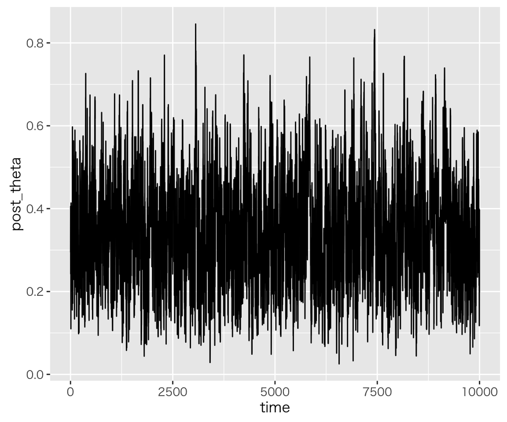

```r
trace2 <- ggplot(sim, aes(x = time, y = post_theta)) + geom_line()
plot(trace2)
```

最初の5000回は捨てた上で、シミュレーション結果から事後分布を描いてみる。

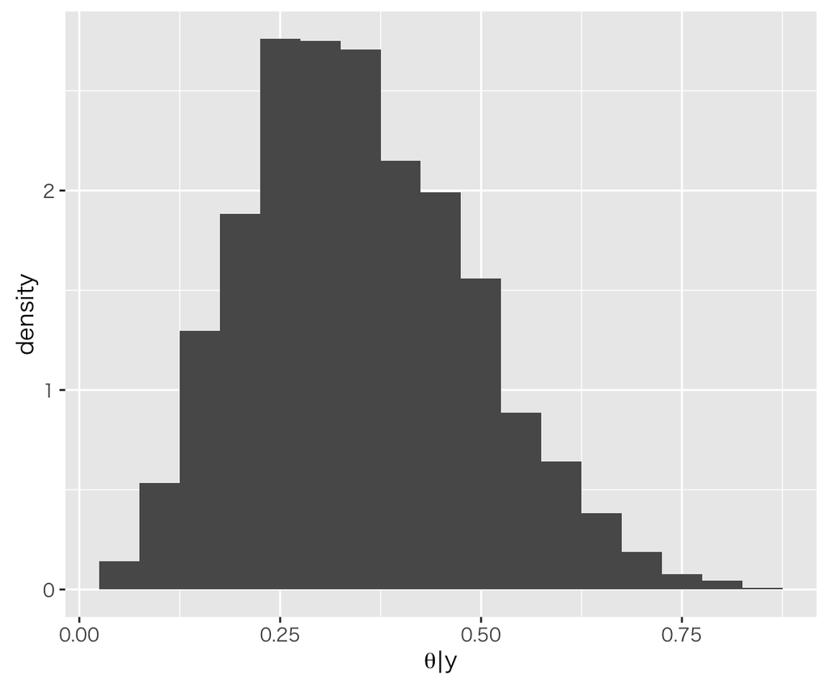

```r
post <- ggplot(sim[5001:10000,],
               aes(x = post_theta, y = ..density..)) +
  geom_histogram(position = "identity", binwidth = 0.05) +
  labs(x = expression(paste(theta, '|', y)))
print(post)
```

## ギブス・サンプリング

ギブス・サンプリングは、推定したいパラメタが複数存在する同時事後分布を得たいときに使う。2枚のコインがあり、投げて表が出る確率をそれぞれ$\theta_1$・ $\theta_2$としよう。以下では、ギブス・サンプリングによって$\theta_1$と$\theta_2$の同時事後分布を生成する。

各コインを10回ずつ投げたところ、コイン1では5回、コイン2では3回表が出た。このときの尤度は、
$$p(D | \theta_1, \theta_2) = \prod_{i=1}^{10}p(y_{1i} | \theta_1, \theta_2) \prod_{i=1}^{10}p(y_{2i} | \theta_1, \theta_2)$$
である。なお、Dは入手したデータ、$y_{1i}$はコイン1での各試行の結果、$y_{2i}$はコイン2での各試行結果を示している。

ここで、各コインのデータは完全に独立であるとすると、
$$p(y_{1i} | \theta_1, \theta_2) = p(y_{1i} | \theta_1)$$
$$p(y_{2i} | \theta_1, \theta_2) = p(y_{2i} | \theta_2)$$
となる。したがって、先の尤度は、
$$p(D | \theta_1, \theta_2) = \theta_1^5 (1 - \theta_1)^5 \theta_2^3 (1 - \theta_2)^7$$
となる。

続いて、パラメタの事前分布を考える。ここでは、それぞれのパラメタに無情報事前分布を仮定して、
$$\theta_1 \sim \mbox{Beta}(1, 1)$$
$$\theta_2 \sim \mbox{Beta}(1, 1)$$
とする。したがって、同時事前分布は、
$$p(\theta_1, \theta_2) = \mbox{beta}(\theta_1 | 1, 1) \mbox{beta}(\theta_2 | 1, 1) \propto \theta_1^{1-1} \theta_2^{1-1}$$
となる。

さて、ギブス・サンプリングは以下の手順で行われる。

1. 各パラメタの初期値を適当に決める。
2. $\theta_2$を固定した上で、$\theta_1$だけを移動させる。
3. データと$\theta_2$に条件付けられた$\theta_1$の事後確率にしたがって、移動先をサンプリングする。
4. $\theta_1$を移動させたら、今度は$\theta_1$を固定した上で、$\theta_2$だけを移動させる。
5. データと$\theta_1$に条件付けられた$\theta_2$の事後確率にしたがって、移動先をサンプリングする。
6. 2〜5を繰り返す。

そこで、これまで導出した尤度と事前確率から、各パラメタの条件付き事後確率を求めよう。$\theta_1$について考えると、
$$\begin{eqnarray*}
p(\theta_1 | \theta_2, D) &=& \frac{p(\theta_1, \theta_2 | D)}{p(\theta_2 | D)} \\
&=& \frac{p(\theta_1, \theta_2 | D)}{\int p(\theta_1, \theta_2 | D) d \theta_1}
\end{eqnarray*}$$
である。事前分布はベータ分布を置いたので、ベイズの定理を使って、
$$\begin{eqnarray*}
p(\theta_1 | \theta_2, D) &=& \frac{\mbox{beta}(\theta_1 | 1+5, 1+5) \mbox{beta}(\theta_2 | 1+3, 1+7)}{\int \mbox{beta}(\theta_1 | 1+5, 1+5) \mbox{beta}(\theta_2 | 1+3, 1+7) d \theta_1} \\
&=& \frac{\mbox{beta}(\theta_1 | 1+5, 1+5) \mbox{beta}(\theta_2 | 1+3, 1+7)}{\mbox{beta}(\theta_2 | 1+3, 1+7)} \\
&=& \mbox{beta}(\theta_1 | 1+5, 1+5)
\end{eqnarray*}$$
と変形できる。同様にして、$\theta_2$の条件付き事後確率も、
$$p(\theta_2 | \theta_1, D) = \mbox{beta}(\theta_2 | 1+3, 1+7)$$
となる。

各パラメタの条件付き事後確率が分かったので、Rでギブス・サンプリングしよう。

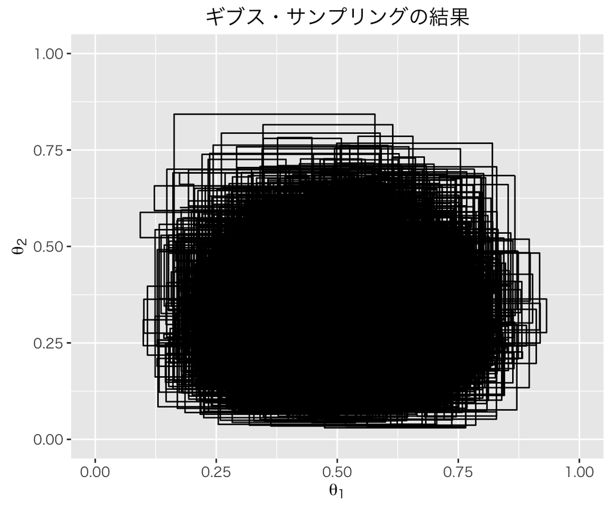

```r
# データの設定
z1 <- 5
z2 <- 3
n1 <- 10
n2 <- 10

# 初期値の設定
theta1 <- runif(1, 0, 1)
theta2 <- runif(1, 0, 1)

# ギブス・サンプリング
for (i in 2:20000){
  if (i %% 2 == 0) {
    theta1[i] <- rbeta(1, z1+1, n1-z1+1)
    theta2[i] <- theta2[i-1]
  } else {
    theta1[i] <- theta1[i-1]
    theta2[i] <- rbeta(1, z2+1, n2-z2+1)
  }
}

# 図示
gibbs <- data.frame(theta1 = theta1, theta2 = theta2)
plot_gibbs <- ggplot(gibbs, aes(x = theta1, y = theta2)) + geom_path() +
  xlim(0, 1) + ylim(0, 1) +
  labs(x = expression(theta[1]), y = expression(theta[2]),
       title = "ギブス・サンプリングの結果")
print(plot_gibbs)
```

```r
# 平均
mean(theta1)
```

```
## [1] 0.5015244
```

```r
mean(theta2)
```

```
## [1] 0.3336342
```

事前分布が無情報なので、平均はほぼデータと同じ確率で表が出ると推定されている。

# 2変量正規分布

BDAに載っていない例ばかりやるのも恐縮なので、Figure 11.2を再現しておく。式や設定は、p.277のExampleを参照。

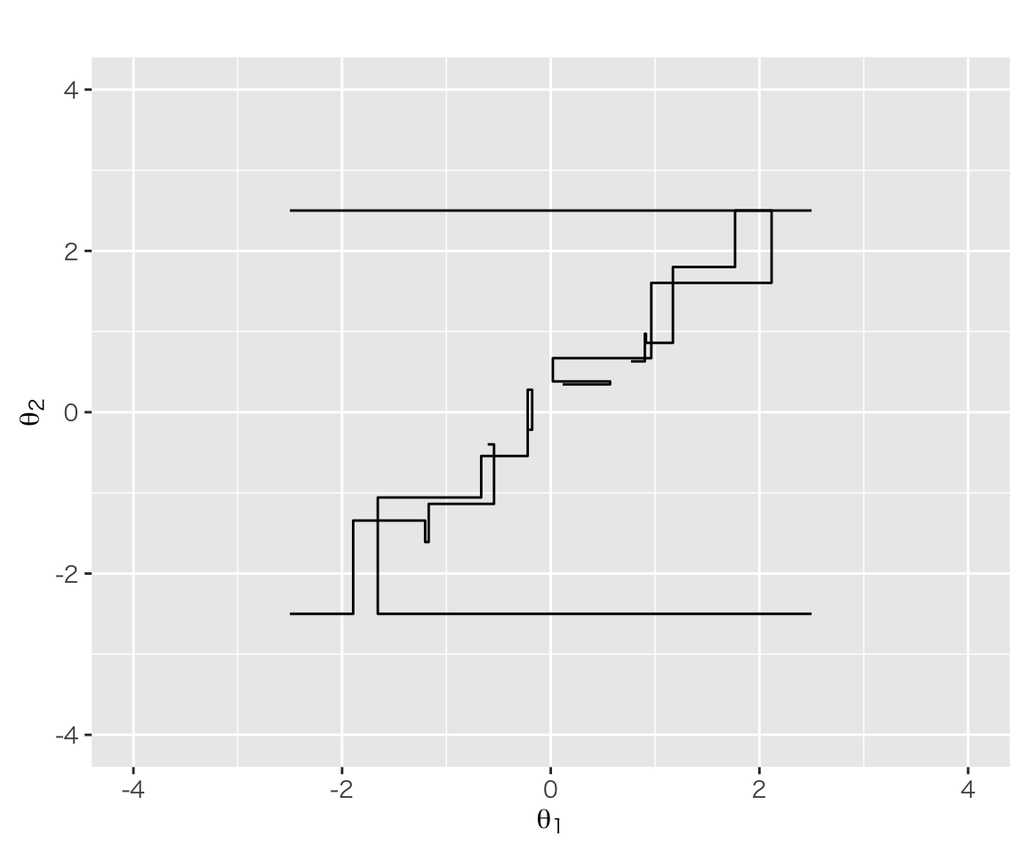

```r
# データの設定
rho <- 0.8
y1 <- 0
y2 <- 0

# 初期値の設定
theta1 <- list(c(2.5), c(2.5), c(-2.5), c(-2.5))
theta2 <- list(c(2.5), c(-2.5), c(2.5), c(-2.5))

# ギブス・サンプリングを4回行う
for (i in 1:4) {
  for (j in 2:500) {
    if (j %% 2 == 0) {
      theta1[[i]][j] <- rnorm(1, rho*(theta2[[i]][j-1] - y2), 1 - rho^2)
      theta2[[i]][j] <- theta2[[i]][j-1]
    } else {
      theta1[[i]][j] <- theta1[[i]][j-1]
      theta2[[i]][j] <- rnorm(1, rho*(theta1[[i]][j-1] - y1), 1 - rho^2)
    }
  }
}

# 図示
## データフレーム化
gibbs <- data.frame(theta1 = c(theta1[[1]], theta1[[2]], theta1[[3]], theta1[[4]]),
                    theta2 = c(theta2[[1]], theta2[[2]], theta2[[3]], theta2[[4]]),
                    trial = c(rep(1, 500), rep(2, 500), rep(3, 500), rep(4, 500)))
## 最初の10回
plot_gibbs <- ggplot(gibbs[c(1:10, 501:510, 1001:1010, 1501:1510),],
                     aes(x = theta1, y = theta2)) +
  geom_path(aes(group = as.factor(trial))) +
  xlim(-4, 4) + ylim(-4, 4) +
  theme(legend.position = "none") +
  labs(x = expression(theta[1]), y = expression(theta[2]),
       title = "")
print(plot_gibbs)
```

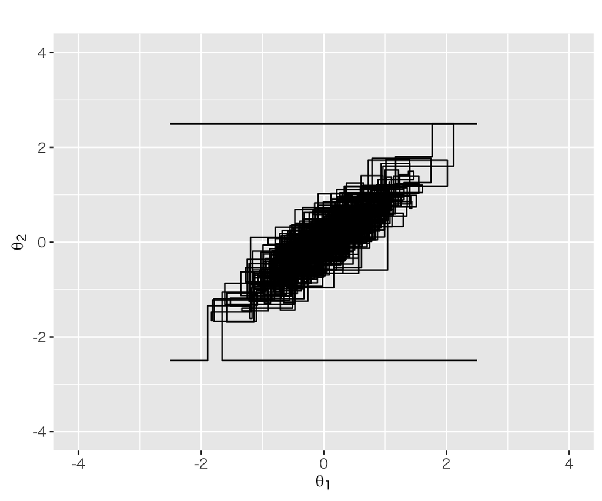

```r
## 全推移
plot_gibbs <- ggplot(gibbs, aes(x = theta1, y = theta2)) +
  geom_path(aes(group = as.factor(trial))) +
  xlim(-4, 4) + ylim(-4, 4) +
  theme(legend.position = "none") +
  labs(x = expression(theta[1]), y = expression(theta[2]),
       title = "")
print(plot_gibbs)
```

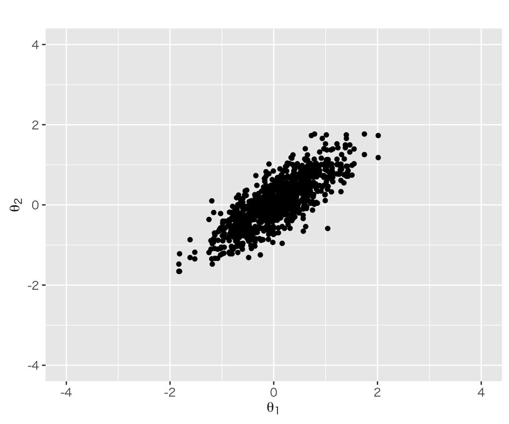

```r
## 各試行の後半だけの散布図
plot_gibbs <- ggplot(gibbs[c(251:500, 750:1000, 1251:1500, 1750:2000),],
                     aes(x = theta1, y = theta2)) +
  geom_point(aes(group = as.factor(trial))) +
  xlim(-4, 4) + ylim(-4, 4) +
  theme(legend.position = "none") +
  labs(x = expression(theta[1]), y = expression(theta[2]),
       title = "")
print(plot_gibbs)
```